# Forecast train occupancy levels in Belgium

Seren Xuan Shi

12/15/2020

# 1. Introduction (Motivation)

On dense railway networks –such as in Belgium– train travelers are frequently confronted with overly occupied trains, especially during peak hours. Crowdedness on trains leads to a deterioration in the quality of service and has a negative impact on the well-being of the passenger. In order to reasonably arrange the occupancy of the train and to maximize cost and efficiency for train operators in Belgium, our project wants to show an occupancy indicator in their route planning applications by the means of predictive modeling.

This app stock data from previous trips and weather patterns to predict train occupancy. This is important for transportation planners as they can run lines more efficiently, knowing what kind of demand exists for certain connections origins and destinations train track is developed first for the transportation planner and then for the commuter. The app will gather real time data about train location, as well as estimate occupancy using our algorithm, the algorithm will inform the planner on which routes to increase or decrease and relay that information to the commuter, who will see how crowded or empty a train is something very important during a pandemic.

That will be created by the transportation service and they will have records of their route use weather delays in profit margins, the company can use GPS monitors on their trains to provide live updates on where their trains are located, which can be relayed to the commuter basing portion of the app users will create real time information by reporting problems with service through a report problem button, within the app interface the commuter would be able to choose from an alphabetized drop down menu displaying the origin and destination. They can favorite their most use route for easier use when the trip is decided the user will get up to date GPS location of the train and estimated time of arrival as well as an estimated occupancy rate based on the models algorithm, and the planners allocation. The best model will be established using a cost benefit analysis to understand occupancy predictions and maximize cost efficiency. This model will correlate accuracy between low, medium and high occupancy. The model that most accurately predicts low and medium occupancy will be implemented as this will help planners consolidate lines and maximize profit and efficiency.

Here is the link to our project’s youtube video! https://youtu.be/yt1P26ML7sQ

Below are some packages to be loaded as well as functions to be set up.

```r
require(foreign)
require(nnet)
require(ggplot2)
require(reshape2)
library(lubridate)
library(dplyr)
library(sf)
library(tidyverse)
library(tidyr)
library(lubridate)
library(ggmap)
library(stplanr)
library(tmap)
library(caret)
library(stringr)
library(viridis)
require(gridExtra)
library(kableExtra)
library(forestmangr)
library(MASS)
library(ggmap)
library(data.table)
library(gganimate)
library (mapview)
library(tigris)
library(riem)
library(gifski)


options(scipen=99)

mapTheme <- theme(plot.title =element_text(size=12),
                  plot.subtitle = element_text(size=8),
                  plot.caption = element_text(size = 6),
                  axis.line=element_blank(),
                  axis.text.x=element_blank(),
                  axis.text.y=element_blank(),
                  axis.ticks=element_blank(),
                  axis.title.x=element_blank(),
                  axis.title.y=element_blank(),
                  panel.background=element_blank(),
                  panel.border=element_blank(),
                  panel.grid.major=element_line(colour = 'transparent'),
                  panel.grid.minor=element_blank(),
                  legend.direction = "vertical",
                  legend.position = "right",
                  plot.margin = margin(1, 1, 1, 1, 'cm'),
                  legend.key.height = unit(1, "cm"), legend.key.width = unit(0.2, "cm"))

plotTheme <- theme(
  plot.title =element_text(size=12),
  plot.subtitle = element_text(size=8),
  plot.caption = element_text(size = 6),
  axis.text.x = element_text(size = 10, angle = 45, hjust = 1),
  axis.text.y = element_text(size = 10),
  axis.title.y = element_text(size = 10),
  # Set the entire chart region to blank
  panel.background=element_blank(),
  plot.background=element_blank(),
  #panel.border=element_rect(colour="#F0F0F0"),
  # Format the grid
  panel.grid.major=element_line(colour="#D0D0D0",size=.2),
  axis.ticks=element_blank())


options(scipen=50, digits=10)

Sys.setenv(LANGUAGE = "en")

setwd("E:\\MUSA508\\Final")
```

# 2. Data Collection

The data we used in this project is based in Belgium and will be applicable to all train lines across the country to create an efficient national train system to help improve commuter satisfaction.

We downloaded the following data from the provided Kaggle dataset: -Train Stations data -Railway data -Lines information data -Trains data

```r
stations <- read.csv("stations.csv")%>%
  st_as_sf(coords = c("longitude", "latitude"), crs = 4326) %>%
  mutate(station_id = as.numeric(str_sub(URI, 31, 39)))%>%
    dplyr::select(-alternative.fr,-alternative.nl,-alternative.de, -alternative.en, -country.code, -URI)
# mapview(list(stations),cex =3,alpha = 0,col.regions = viridis(1))

rail <- st_read("E:/MUSA508/Final/belgium-railways-shape/railways.shp")%>%
  filter(type=="rail")
# mapview(rail)


line <- st_read("line_info.csv")

trains <-
  read.csv("trains_train.csv") %>%
  mutate(from = as.numeric(as.character(from)),
  to = as.numeric(as.character(to))) %>%
  left_join(dplyr::select(stations, station_id, avg_stop_times,name), by = c("from" = "station_id")) %>%
  st_sf() %>% mutate(from.X = st_coordinates(.)[,1],
  from.Y = st_coordinates(.)[,2]) %>%
  st_drop_geometry() %>%
  left_join(dplyr::select(stations, station_id, avg_stop_times), by = c("to" = "station_id")) %>%
  st_sf() %>% mutate(to.X = st_coordinates(.)[,1],
  to.Y = st_coordinates(.)[,2]) %>%
  st_drop_geometry() %>%
  mutate(distance = sqrt((from.X - to.X)^2 + (from.Y - to.Y)^2),
         stop_times_from = avg_stop_times.x,
         stop_times_to = avg_stop_times.y,) %>%
    dplyr::select(-avg_stop_times.x, -avg_stop_times.y)%>%
  arrange(-distance)


trains$occ2 <- ordered(trains$occupancy,levels = c("low", "medium", "high"))
trains$OD <- paste (trains$from, trains$to, sep= "-")
trains$date_time <- paste(trains$date, trains$time)
trains$date_time <- parse_date_time(trains$date_time, "ymd %I:%M:%S %p")


trains <-
    trains %>%
    mutate(veh = substr(vehicle,1,1),
          interval60 = floor_date(ymd_hms(date_time), unit = "hour"),
           interval15 = floor_date(ymd_hms(date_time), unit = "15 mins"),
           week = week(interval60),
           dotw = wday(interval60),
           veh = substr(vehicle,1,1))

trains <-
    trains %>%
    mutate(veh = substr(vehicle,1,1),
          interval60 = floor_date(ymd_hms(date_time), unit = "hour"),
           interval15 = floor_date(ymd_hms(date_time), unit = "15 mins"),
           week = week(interval60),
          # dotw = wday(interval60),
           veh = substr(vehicle,1,1),
           hour = as.numeric(substr(date_time, 12, 13)),
           weekend = ifelse(dotw == "6" | dotw == "7",1,0),
          mor.jam = ifelse(hour>= 6 & hour<=10 & weekend == "0",1,0),
          eve.jam = ifelse(hour>= 15 & hour<= 19 & weekend == "0",1,0),
          hour = factor(hour),
          weekend = factor(weekend),
          mor.jam = factor(mor.jam),
          eve.jam = factor(eve.jam),
          from = factor(from),
          dotw = factor(wday(date_time)),
          to = factor (to))
```

We also include other data to enrich our model: -Weather data -Facility data

```r
weather_july1 <- read.csv("E:/MUSA508/Final/KaggleTrainOccupancy-master/weather_data_july_1.csv")
weather_july2 <- read.csv("E:/MUSA508/Final/KaggleTrainOccupancy-master/weather_data_july_2.csv")
weather_aug1 <- read.csv("E:/MUSA508/Final/KaggleTrainOccupancy-master/weather_data_aug_1.csv")
weather_aug2 <- read.csv("E:/MUSA508/Final/KaggleTrainOccupancy-master/weather_data_aug_2.csv")
weather_sep1 <- read.csv("E:/MUSA508/Final/KaggleTrainOccupancy-master/weather_data_sep_1.csv")
weather_sep2 <- read.csv("E:/MUSA508/Final/KaggleTrainOccupancy-master/weather_data_sep_2.csv")
weather_oct1 <- read.csv("E:/MUSA508/Final/KaggleTrainOccupancy-master/weather_data_oct_1.csv")
weather_oct2 <- read.csv("E:/MUSA508/Final/KaggleTrainOccupancy-master/weather_data_oct_2.csv")

weather1 <-
    mutate(weather_july1, interval60 = ymd_h(substr(date_time,1,13))) %>%
    mutate(week = week(interval60),
           dotw = wday(interval60)) %>%
    group_by(interval60,station_name) %>%
    dplyr::summarize(Temperature = max(temperature),
              Humidity = max(humidity),
              Wind_Speed = max(windspeed),
              Visibility = max(visibility))
weather2 <-
    mutate(weather_july2, interval60 = ymd_h(substr(date_time,1,13))) %>%
    mutate(week = week(interval60),
           dotw = wday(interval60)) %>%
    group_by(interval60,station_name) %>%
    dplyr::summarize(Temperature = max(temperature),
              Humidity = max(humidity),
              Wind_Speed = max(windspeed),
              Visibility = max(visibility))
weather3 <-
    mutate(weather_aug1, interval60 = ymd_h(substr(date_time,1,13))) %>%
    mutate(week = week(interval60),
           dotw = wday(interval60)) %>%
    group_by(interval60,station_name) %>%
    dplyr::summarize(Temperature = max(temperature),
              Humidity = max(humidity),
              Wind_Speed = max(windspeed),
              Visibility = max(visibility))
weather4 <-
    mutate(weather_aug2, interval60 = ymd_h(substr(date_time,1,13))) %>%
    mutate(week = week(interval60),
           dotw = wday(interval60)) %>%
    group_by(interval60,station_name) %>%
    dplyr::summarize(Temperature = max(temperature),
              Humidity = max(humidity),
              Wind_Speed = max(windspeed),
              Visibility = max(visibility))
weather5 <-
    mutate(weather_sep1, interval60 = ymd_h(substr(date_time,1,13))) %>%
    mutate(week = week(interval60),
           dotw = wday(interval60)) %>%
    group_by(interval60,station_name) %>%
    dplyr::summarize(Temperature = max(temperature),
              Humidity = max(humidity),
              Wind_Speed = max(windspeed),
              Visibility = max(visibility))
weather6 <-
    mutate(weather_sep2, interval60 = ymd_h(substr(date_time,1,13))) %>%
    mutate(week = week(interval60),
           dotw = wday(interval60)) %>%
    group_by(interval60,station_name) %>%
    dplyr::summarize(Temperature = max(temperature),
              Humidity = max(humidity),
              Wind_Speed = max(windspeed),
              Visibility = max(visibility))
weather7 <-
    mutate(weather_oct1, interval60 = ymd_h(substr(date_time,1,13))) %>%
    mutate(week = week(interval60),
           dotw = wday(interval60)) %>%
    group_by(interval60,station_name) %>%
    dplyr::summarize(Temperature = max(temperature),
              Humidity = max(humidity),
              Wind_Speed = max(windspeed),
              Visibility = max(visibility))
weather8 <-
    mutate(weather_oct2, interval60 = ymd_h(substr(date_time,1,13))) %>%
    mutate(week = week(interval60),
           dotw = wday(interval60)) %>%
    group_by(interval60,station_name) %>%
    dplyr::summarize(Temperature = max(temperature),
              Humidity = max(humidity),
              Wind_Speed = max(windspeed),
              Visibility = max(visibility))

weather1$station_date <- paste (weather1$station_name, weather1$interval60, sep= "-")
weather2$station_date <- paste (weather2$station_name, weather2$interval60, sep= "-")
weather3$station_date <- paste (weather3$station_name, weather3$interval60, sep= "-")
weather4$station_date <- paste (weather4$station_name, weather4$interval60, sep= "-")
weather5$station_date <- paste (weather5$station_name, weather5$interval60, sep= "-")
weather6$station_date <- paste (weather6$station_name, weather6$interval60, sep= "-")
weather7$station_date <- paste (weather7$station_name, weather7$interval60, sep= "-")
weather8$station_date <- paste (weather8$station_name, weather8$interval60, sep= "-")

weather <- rbind(weather1,weather2,weather3,weather4,weather5,weather6,weather7,weather8)

trains$station_date <- paste (trains$name, trains$interval60, sep= "-")

trains <- merge(x=trains,y=weather[,c("station_date","Temperature","Humidity","Wind_Speed","Visibility")], by = "station_date", all.x=TRUE)

trains$Temperature[is.na(trains$Temperature)] <- 0
trains$Humidity[is.na(trains$Humidity)] <- 0
trains$Wind_Speed[is.na(trains$Wind_Speed)] <- 0
trains$Visibility[is.na(trains$Visibility)] <- 0
```

```r
facility<-read_csv("E:\\MUSA508\\Final\\stations-master\\stations-master\\facilities.csv")

facility[is.na(facility)] <- 0

facility <-
  facility %>%
  mutate(facility_sum = dplyr::select(.,ticket_vending_machine:audio_induction_loop) %>%
           rowSums())
facility <-
  facility %>%
  dplyr::select(name,facility_sum)

stations <- merge(stations,facility,by="name",all.x=T,all.y=F)
stations[is.na(stations)] <- 0
```

# 3. Exploratory analysis

To create the best model we began by plotting the points of the train station that make up the data set to begin to understand that geographic location and their connection to other train stations.

We also part of the train line to understand the connection between different stations and the occupancy rate for different lines. We found that most ships are medium and low occupancy in yellow and pink respectively. It’s important for planners to know which connections have higher low occupancy. Because will ultimately determine how change will be allocated to coincide with rider demand.

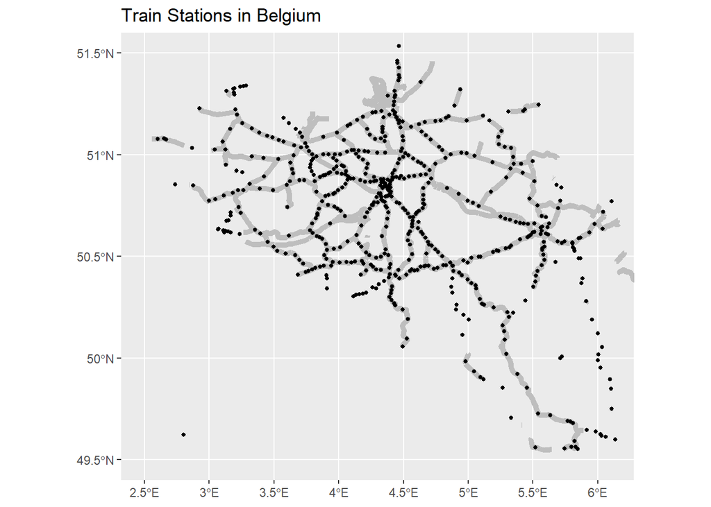

```r
ggplot() +
  geom_sf(data=rail, inherit.aes = FALSE,na.rm=T, col="grey", lwd=1.8 )+
  geom_sf(data=stations, size = 1,inherit.aes = FALSE)+
   ylim(min(49.5), max(51.5))+ #lat
  xlim(min(2.5), max(6.1))+
    labs(title="Train Stations in Belgium")
```

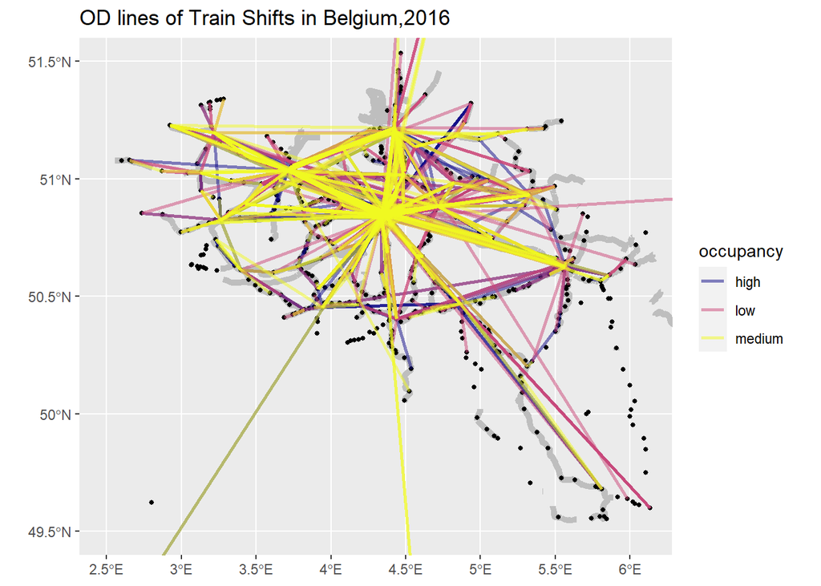

```r
new_t <- trains%>%
  mutate(new = 1)%>%
  dplyr::select(OD, new)%>%
  group_by(OD) %>%
  summarise( count = sum (new))

new_t <- separate(new_t,OD,into=c("from","to"), sep="-")
new_t <- subset(new_t, new_t$to!="1000000" & new_t$from!="1000000" & new_t$to!="0" & !is.na(new_t$to) & !is.na(new_t$from) & new_t$to!="NA" & new_t$from!="NA")

new_t <- subset(new_t, new_t$to!=new_t$from)
new_t$from <- as.numeric(as.character(new_t$from))
new_t$to <- as.numeric(new_t$to)

station_extract <- stations%>%
  mutate(to = station_id)%>%
  dplyr::select(to)

z <- station_extract
l <- od2line(flow = new_t, zones = z)
l$OD <-  paste (l$from, l$to, sep= "-")
try <- merge(l,trains, by = "OD", all.x=T, all.y=F)

ggplot(try)+
  geom_sf(data=rail, inherit.aes = FALSE,na.rm=T, col="grey", lwd=1.8 )+
geom_sf(data=stations, size = 1,inherit.aes = FALSE)+
geom_sf(data=try, aes(color = occupancy), alpha=0.5,inherit.aes = FALSE, lwd = 1)+
  scale_color_viridis(discrete=TRUE, option = "C") +
#geom_sf(stat_order_sf,aes(color = vehicle_id), size=0.3)+
 # theme(legend.position="none")+
   ylim(min(49.5), max(51.5))+ #lat
  xlim(min(2.5), max(6.1))+ #long
  labs(title="OD lines of Train Shifts in Belgium,2016")
```

```r
train_sf <- merge(l[,c("geometry","OD")], trains, by = "OD", alll=T)
```

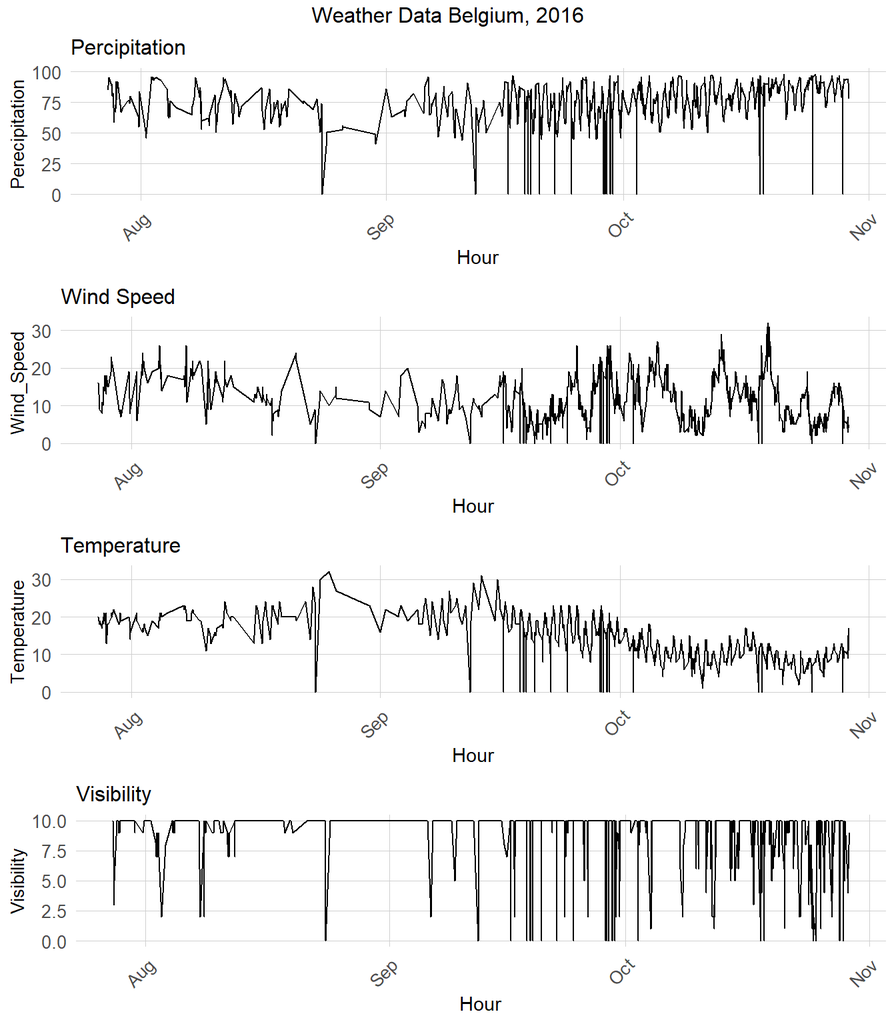

```r
grid.arrange(
  ggplot(trains, aes(interval60,Humidity)) + geom_line() +
    labs(title="Percipitation", x="Hour", y="Perecipitation") + plotTheme,
  ggplot(trains, aes(interval60,Wind_Speed)) + geom_line() +
    labs(title="Wind Speed", x="Hour", y="Wind_Speed") + plotTheme,
  ggplot(trains, aes(interval60,Temperature)) + geom_line() +  #B1339E
    labs(title="Temperature", x="Hour", y="Temperature") + plotTheme,
 ggplot(trains, aes(interval60,Visibility)) + geom_line() +
    labs(title="Visibility", x="Hour", y="Visibility") + plotTheme,
 ncol = 1,
  top="Weather Data Belgium, 2016")
```

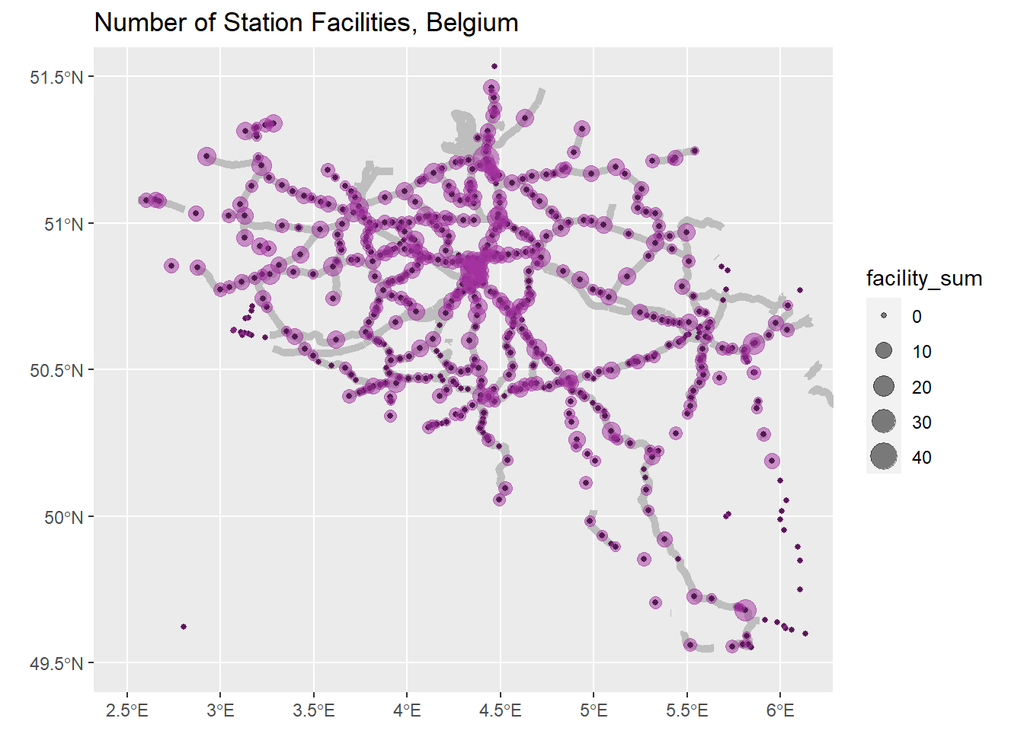

```r
ggplot() +

  geom_sf(data=rail, inherit.aes = FALSE,na.rm=T, col="grey", lwd=1.8 )+
  geom_sf(data=stations, size = 1,inherit.aes = FALSE)+
  geom_sf(data = stations,aes(size= facility_sum,col= I('#A3319F')),alpha=0.5)+
   ylim(min(49.5), max(51.5))+ #lat
  xlim(min(2.5), max(6.1))+
    labs(title="Number of Station Facilities, Belgium")
```

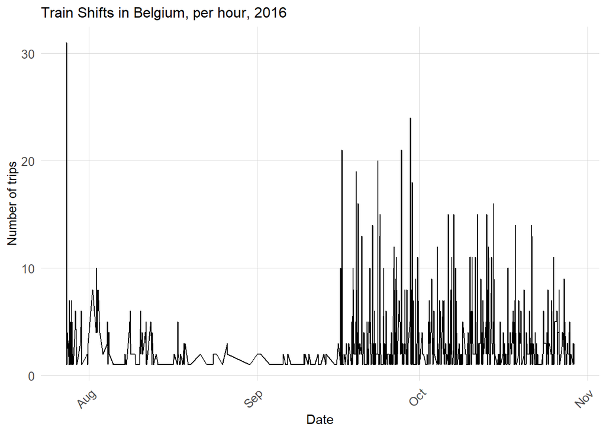

```r
ggplot(trains %>%
         group_by(interval60) %>%
         tally())+
  geom_line(aes(x = interval60, y = n))+
  labs(title="Train Shifts in Belgium, per hour, 2016",
       x="Date",
       y="Number of trips")+
  plotTheme
```

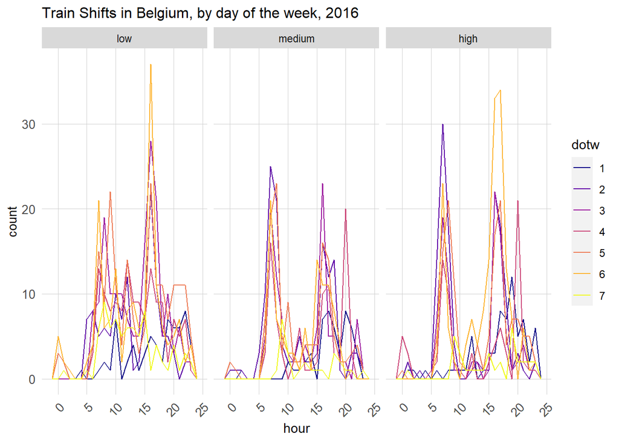

```r
ggplot(trains %>%
         mutate(hour = hour(interval60)) %>%
         filter(occ2 == "high" | occ2 == "medium" | occ2 == "low"), aes(hour, color = dotw))+
  geom_freqpoly(binwidth = 1)+
  scale_color_viridis(discrete=TRUE, option = "C") +
  facet_wrap(~occ2,ncol=3) +
  labs(title="Train Shifts in Belgium, by day of the week, 2016") +
  plotTheme
```

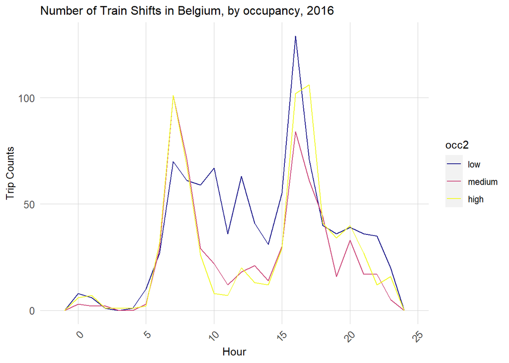

```r
ggplot(trains %>% mutate(hour = hour(interval60)))+
     geom_freqpoly(aes(hour, color = occ2), binwidth = 1)+
  scale_color_viridis(discrete=TRUE, option = "C") +
  labs(title="Number of Train Shifts in Belgium, by occupancy, 2016",
       x="Hour",
       y="Trip Counts")+
     plotTheme
```

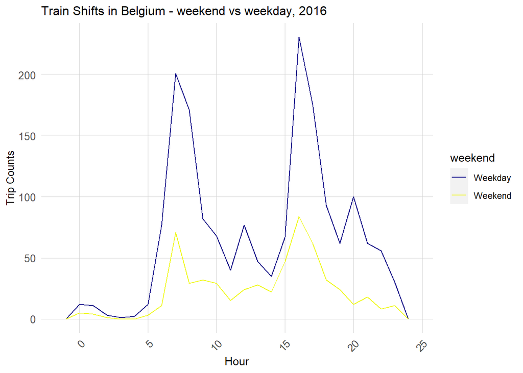

```r
ggplot(trains %>%
         mutate(hour = hour(interval15),
                weekend = ifelse(dotw %in% c("6", "7"), "Weekend", "Weekday")))+
     geom_freqpoly(aes(hour, color = weekend), binwidth = 1)+
  scale_color_viridis(discrete=TRUE, option = "C") +
  labs(title="Train Shifts in Belgium - weekend vs weekday, 2016",
       x="Hour",
       y="Trip Counts")+
     plotTheme
```

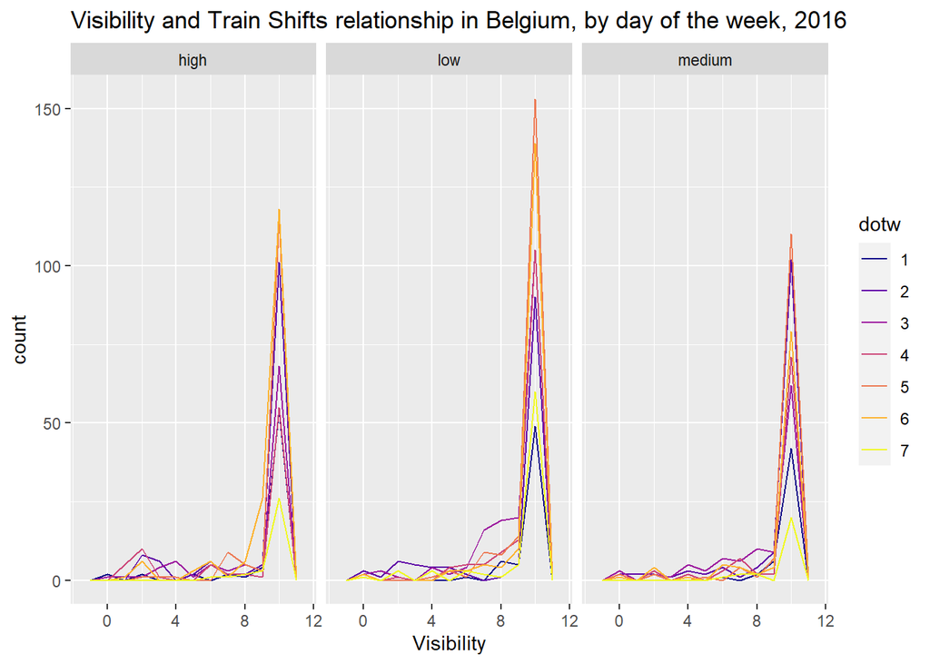

```r
ggplot(trains %>%
         mutate(hour = hour(interval60)) %>%
         filter(occ2 == "high" | occ2 == "medium" | occ2 == "low"), aes(Visibility, color = dotw))+
  geom_freqpoly(binwidth = 1)+
  scale_color_viridis(discrete=TRUE, option = "C") +
  facet_wrap(~occupancy,ncol=3) +
  labs(title="Visibility and Train Shifts relationship in Belgium, by day of the week, 2016")
```

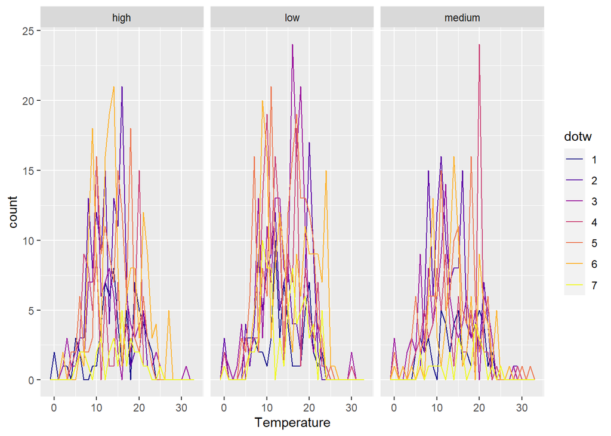

```r
ggplot(trains %>%
         mutate(hour = hour(interval60)) %>%
         filter(occ2 == "high" | occ2 == "medium" | occ2 == "low"), aes(Temperature, color = dotw))+
  geom_freqpoly(binwidth = 1)+
  scale_color_viridis(discrete=TRUE, option = "C") +
  facet_wrap(~occupancy,ncol=3)
```

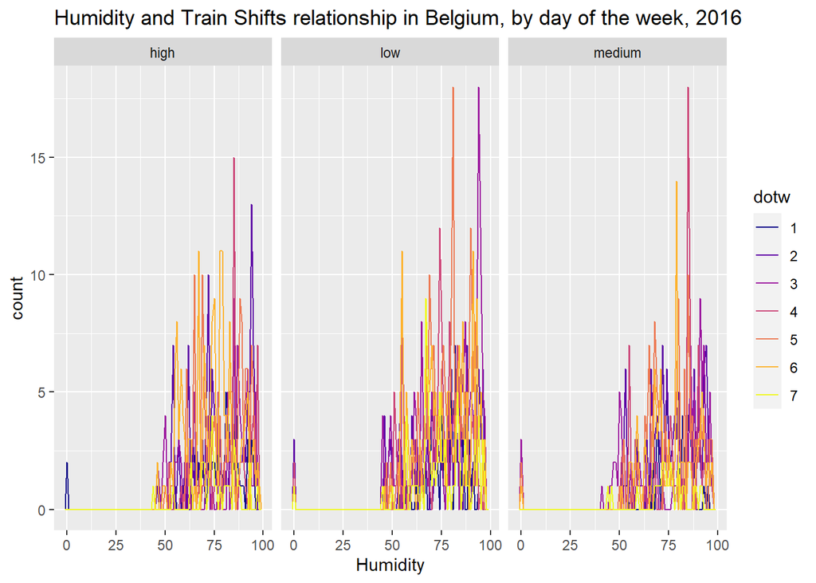

```r
  labs(title="Temperature and Train Shifts relationship in Belgium, by day of the week, 2016")

ggplot(trains %>%
         mutate(hour = hour(interval60)) %>%
         filter(occ2 == "high" | occ2 == "medium" | occ2 == "low"), aes(Humidity, color = dotw))+
  geom_freqpoly(binwidth = 1)+
  scale_color_viridis(discrete=TRUE, option = "C") +
  facet_wrap(~occupancy,ncol=3) +
  labs(title="Humidity and Train Shifts relationship in Belgium, by day of the week, 2016")
```

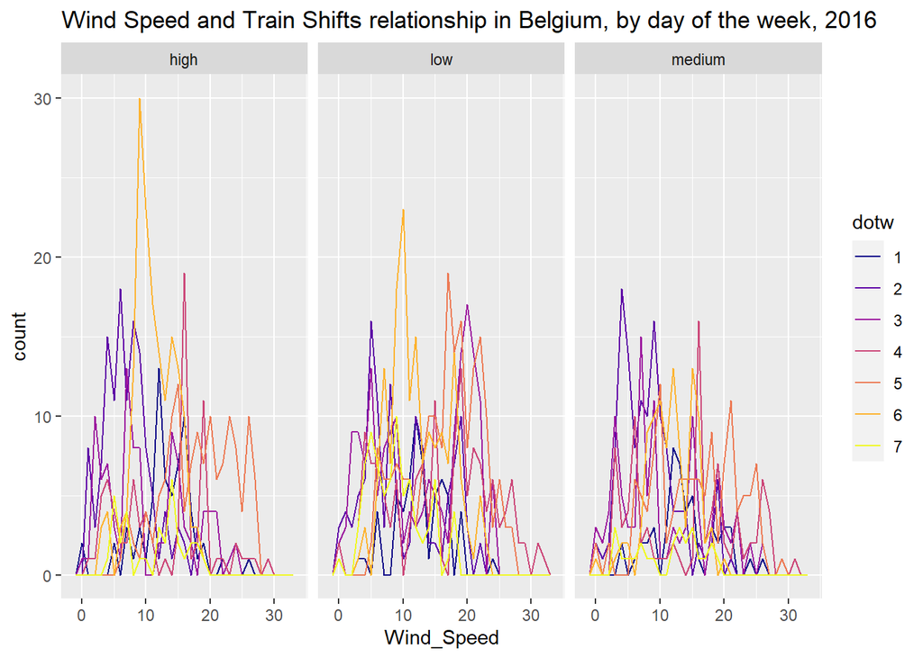

```r
ggplot(trains %>%
         mutate(hour = hour(interval60)) %>%
         filter(occ2 == "high" | occ2 == "medium" | occ2 == "low"), aes(Wind_Speed, color = dotw))+
  geom_freqpoly(binwidth = 1)+
   scale_color_viridis(discrete=TRUE, option = "C") +
  facet_wrap(~occupancy,ncol=3) +
  labs(title="Wind Speed and Train Shifts relationship in Belgium, by day of the week, 2016")
```

# 4. Spatial Process

In this section we analysis the relationship between the occupancy level and the trips characteristic.

-OD pairs and the occupancy level

```r
occ_OD <- trains%>%
  group_by(OD)%>%
   count(occ2)%>%
    mutate(count = n)%>%
   dplyr::select(-n)
occ_OD_df <- as.data.frame(occ_OD)
head(occ_OD[order(-occ_OD_df$count),],10)
```

```
## # A tibble: 10 x 3
## # Groups:   OD [6]
##    OD              occ2   count
##    <chr>           <ord>  <int>
##  1 8892007-8891009 low       22
##  2 8833001-8812005 high      21
##  3 8892007-8814001 medium    20
##  4 8892007-8814001 high      19
##  5 8812005-8813003 medium    16
##  6 8813003-0       medium    16
##  7 8891009-8892007 low       16
##  8 8813003-0       high      15
##  9 8891009-8892007 medium    15
## 10 8892007-8891009 medium    15
```

```r
l2 <- merge(l, occ_OD, by="OD", all.x=TRUE)


l2$occ2 <- factor(l2$occ2, level=c("low","medium","high"))
train_sf$OD_occ <- factor(ifelse(train_sf$OD %in% occ_OD$OD, train_sf$OD, "1"))
```

-Start station and the occupancy level

```r
occ_from <- trains%>%
  group_by(from)%>%
   count(occ2)%>%
  mutate(count = n,
         station_id= from)%>%
  dplyr::select(-n)

#merge with sf
stations <- stations%>%
  mutate(Geom = gsub('[(c)°]', '', geometry)) %>%
  separate(col = Geom, into = c('lat', 'lon'), sep = '\\,')
occ_from <- merge(stations["station_id"], occ_from, by= "station_id",all.y=T)
occ_from_df <- as.data.frame(occ_from)%>%
  dplyr::select(-geometry)%>%
  round_df(3)
head(occ_from_df[order( -occ_from_df$count),],10)
```

```
##     station_id    from   occ2 count
## 335    8892007 8892007    low    79
## 337    8892007 8892007 medium    75
## 64     8812005 8812005    low    67
## 201    8833001 8833001   high    66
## 336    8892007 8892007   high    66
## 63     8812005 8812005   high    64
## 84     8813003 8813003 medium    60
## 85     8813003 8813003   high    55
## 62     8812005 8812005 medium    48
## 86     8813003 8813003    low    45
```

-End station and the occupancy level

```r
occ_to <- trains%>%
  group_by(to)%>%
   count(occ2)%>%
  mutate(count = n,
         station_id= to)%>%
  dplyr::select(-n)

#merge with sf
occ_to <- merge(stations[c("geometry","station_id")], occ_to, by= "station_id",all.y=T)

occ_to_df <- as.data.frame(occ_to)%>%
  dplyr::select(-geometry)%>%
  round_df(3)
head(occ_to_df[order( -occ_to_df$count),],10)
```

```
##     station_id      to   occ2 count
## 73     8812005 8812005   high    73
## 377    8892007 8892007    low    73
## 97     8814001 8814001 medium    64
## 72     8812005 8812005    low    62
## 98     8814001 8814001   high    59
## 94     8813003 8813003   high    58
## 95     8813003 8813003 medium    58
## 378    8892007 8892007 medium    57
## 99     8814001 8814001    low    53
## 93     8813003 8813003    low    50
```

-Vehicle and the occupancy level

```r
occ_veh <- trains%>%
  group_by(vehicle)%>%
   count(vehicle)%>%
  mutate(count = n)%>%
dplyr::select(-n)
occ_veh_df <- as.data.frame(occ_veh)%>%
  round_df(3)
head(occ_veh_df[order( -occ_veh_df$count),],10)
```

```
##     vehicle count
## 27   IC1518    36
## 392   IC429    29
## 25   IC1515    22
## 358   IC407    19
## 491   IC736    17
## 645   P7305    17
## 67   IC1807    16
## 313  IC3631    16
## 1      1828    14
## 11     8015    14
```

```r
trains_to <- merge(trains, stations,  by.x = "to", by.y = "station_id") %>%
   st_as_sf()

trains_from <- merge(trains, stations,  by.x = "from", by.y = "station_id") %>%
   st_as_sf()

sort(summary(trains_to$vehicle,maxsum=1500),decreasing = TRUE)
```

```
##     Class      Mode    Length
## character character      2255
```

```r
sort(summary(trains_from$vehicle,maxsum=1500),decreasing = TRUE)
```

```
##     Class      Mode    Length
## character character      2287
```

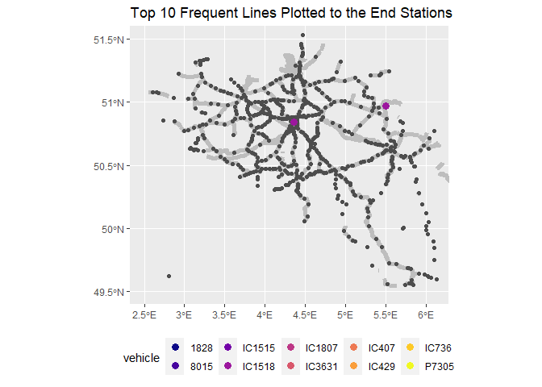

```r
top_10=c("IC1518","IC429","IC1515","IC407","IC736","P7305","IC1807","IC3631","1828","8015")


p=ggplot()+
  geom_sf(data=rail,colour = "grey",lwd=1.8)+
  geom_sf(data=stations, size = 1.5,colour = "grey30",inherit.aes = FALSE)+
  geom_sf(data=subset(trains_from, trains_from$vehicle %in% top_10),aes(colour = vehicle),size=3,show.legend = "point")+
  scale_color_viridis(discrete=TRUE, option = "C") +
  labs(title="Top 10 Frequent Lines Plotted to the Start Stations")+
  theme(legend.position = "bottom") + transition_manual(factor(vehicle, levels = top_10), cumulative = TRUE)+
  ylim(min(49.5), max(51.5))+ #lat
  xlim(min(2.5), max(6.1))

animate(p,duration=10)



p=ggplot()+
  geom_sf(data=rail,colour = "grey",lwd=1.8)+
  geom_sf(data=stations, size = 1.5,colour = "grey30",inherit.aes = FALSE)+
  geom_sf(data=subset(trains_to, trains_to$vehicle %in% top_10),aes(colour = vehicle),size=3,show.legend = "point")+
  scale_color_viridis(discrete=TRUE, option = "C") +
  labs(title="Top 10 Frequent Lines Plotted to the End Stations")+
  theme(legend.position = "bottom") + transition_manual(factor(vehicle, levels = top_10), cumulative = TRUE)+
  ylim(min(49.5), max(51.5))+ #lat
  xlim(min(2.5), max(6.1))

animate(p,duration=10)
```

```r
#seperate and clean staion
line$nr_of_stops <- as.numeric(as.character(line$nr_of_stops))
sep_stat_line <- as.data.frame(str_split_fixed(line$stopping_station_ids, ",",34))

sep_stat_line <- sep_stat_line %>%
  mutate_all(funs(gsub("'", "", .)))%>%
  mutate_all(funs(gsub("]", "", .)))%>%
  mutate(V1 = substr(V1, 2, 10))

# join station with line info
sep_stat_line <- cbind(line,sep_stat_line)
sep_stat_line <-
  sep_stat_line%>%
  dplyr::select(-Unnamed..0, -Unnamed..0.1)

# wide to long
v_stat_line <- reshape(sep_stat_line,
                       varying=c(6:39),
                       timevar = "Order",
                       idvar=c("vehicle_id"),
                       v.names="station_id",
                       direction="long")
v_stat_line <- v_stat_line%>%mutate_all(funs(gsub(" ", "", .)))%>%
  mutate(station_id = substr(station_id,3,9))%>%
  filter(station_id!="")%>%
  dplyr::select(-stopping_station_ids)

# add geomtry to each station
stat_order_sf <- merge(stations[c("avg_stop_times", "station_id","geometry")], v_stat_line, by = "station_id",all=T)

# if the % of certain type of occupancy is larger than 0.75 (and count >=5), then 1,  otherwise 0
stat_order_sf$occ_veh<- ifelse(stat_order_sf$vehicle_id %in% occ_veh$vehicle_id,1,0)

# only select the stations exist in trains
stat_order_sf <- subset(stat_order_sf, stat_order_sf$station_id %in% trains$from | stat_order_sf$station_id %in% trains$to)

# merge occupancy into station order_sf
veh_sf <- merge(stat_order_sf,occ_veh, by.x = "vehicle_id",by.y = "vehicle", all.x=T)


train_sf<-merge(trains,train_sf,all=F)
train_sf<-merge(train_sf, stations,by.x ="from" , by.y = "station_id")
train_sf$vehicle <- as.character(train_sf$vehicle)
train_sf$veh_occ <- as.factor(ifelse(train_sf$vehicle %in% occ_veh$vehicle, train_sf$vehicle, "1"))
```

# 4. Modeling

We uses Multinomial Logistic Regression to train the model. There are three occupancy outcomes, low, medium and high, so we are going to have a three-way confusion matrix.

```r
train_sf$veh <- as.factor(train_sf$veh)
train_sf$week <- as.factor(train_sf$week)

set.seed(0415)
trainIndex <- createDataPartition(
              y = paste(train_sf$occ2, train_sf$to, train_sf$veh_occ,  train_sf$OD_occ, train_sf$from, train_sf$dowt, p = .75),
              list = FALSE,
              times = 1)
yTrain <- train_sf[ trainIndex,]
yTest  <- train_sf[-trainIndex,]

m1 <- multinom(occ2 ~  week + dotw + veh + hour  + mor.jam + eve.jam + distance + from + to + OD_occ + veh_occ + stop_times_from + stop_times_to + Temperature + Humidity + Wind_Speed+Visibility, data = yTrain, MaxNWts =10000000)
testProbs <- data.frame(Observe = as.factor(yTest$occ2),
                        Predict = predict(m1, newdata=yTest, "class"),
                 pre = predict(m1, newdata=yTest, "probs"),
                 from = yTest$from,
                 to = yTest$to,
                 OD = yTest$OD,
                 week = yTest$week,
                 hour = yTest$hour,
                 interval60 = yTest$interval60,
                 date = yTest$date)
testProbs <- merge(l[c("geometry","OD")], testProbs, by="OD", all.y=T)
testProbs <- testProbs[c(7,8,9, 10,11,12,1,2,3,4,5,6,13)]
testProbs_table <- as.data.frame(testProbs)%>%
  round_df(3)%>%
  dplyr::select(from, to, date, Observe, Predict, pre.low, pre.high, pre.medium)
head(testProbs_table,100)
```

```
##        from      to       date Observe Predict pre.low pre.high pre.medium
## 1   8811007 8812005 2016-09-28     low     low   1.000    0.000      0.000
## 2   8811007 8812005 2016-09-28     low     low   1.000    0.000      0.000
## 3   8811106 8811916 2016-10-04     low     low   1.000    0.000      0.000
## 4   8811106 8811916 2016-10-04     low     low   1.000    0.000      0.000
## 5   8811106 8811916 2016-10-11     low     low   1.000    0.000      0.000
## 6   8811106 8811916 2016-10-12     low     low   1.000    0.000      0.000
## 7   8811106 8811916 2016-10-19     low     low   1.000    0.000      0.000
## 8   8811189 8813003 2016-10-24  medium  medium   0.000    0.000      1.000
## 9   8811189 8821121 2016-09-19  medium  medium   0.000    0.000      1.000
## 10  8811189 8822004 2016-09-26    high    high   0.000    1.000      0.000
## 11  8811189 8822004 2016-10-22    high    high   0.000    1.000      0.000
## 12  8811213 8813003 2016-09-22     low     low   1.000    0.000      0.000
## 13  8811247 8811254 2016-10-10    high    high   0.322    0.388      0.290
## 14  8811247 8811254 2016-10-10     low    high   0.322    0.388      0.290
```

[output cut: 86 more lines]

# 5. Goodness of fit

## 5.1 Cost benefit analysis

According to our use case, this software is designed for railway transportation planners, we hope to help them reduce expenditures while optimizing the needs of transportation systems. We classify the nine prediction results to develop a cost benefit analysis.

Multiple models will be run through our state of the cost benefit analysis software to determine which algorithm will best help transportation planners render high profit and efficiency while delivering a pleasant experience for the commuter. We hope that the algorithm and its ability to predict train occupancy will make the train riding experience more attractive to Belgians and more cost efficient for planners.

If we can successfully predict the route, we expect that the optimal algorithm can optimize the total revenue.We are going to make the following assumptions about the Income and Cost of the occupancy prediction change: - We assume the average ticket fee per passenger is €6. - We assume the capacity of each trip is 400 (80*5 coach). - We assume the cost on increasing of capacity or coach is €300. - We assume the about €300, which corresponds to 100 capacity increase. - For highly occupied trips, we assumed 100 additional passengers will get into the train if we increase the capacity of that trip.

Based on these assumptions, we have established a profit calculation method for each prediction result and the observed comparison.

```r
cost_benefit_table <-
   testProbs_table %>%
   na.omit() %>%
      count(Observe, Predict) %>%
      summarize(Low_Low = sum(n[Observe=='low' & Predict=='low']),
                Low_Medium = sum(n[Observe=='low' & Predict=='medium']),
                Low_High = sum(n[Observe=='low' & Predict=='high']),
                Medium_low = sum(n[Observe=='medium' & Predict=='low']),
                Medium_Medium = sum(n[Observe=='medium' & Predict=='medium']),
                Medium_High = sum(n[Observe=='medium' & Predict=='high']),
                High_Low = sum(n[Observe=='high' & Predict=='low']),
                High_Medium = sum(n[Observe=='high' & Predict=='medium']),
                High_High = sum(n[Observe=='high' & Predict=='high']),
                SUM = sum(n)
                ) %>%
       gather(Variable, Count)%>%
         mutate(Income =
               ifelse(Variable == "Low_Low", 0,
               ifelse(Variable == "Low_Medium", 0,
              ifelse(Variable == "Low_High", 0,
               ifelse(Variable == "Medium_low", 0,
              ifelse(Variable == "Medium_Medium", 0,
                ifelse(Variable == "Medium_High", 0,
               ifelse(Variable == "High_Low",'-(6*100)',
               ifelse(Variable == "High_Medium", 0,
               ifelse(Variable == "High_High", '6*100',
                      ifelse(Variable == "SUM",(-(6*100)+6*100) ,0))))))))))) %>%
           mutate(Cost =
               ifelse(Variable == "Low_Low", -300,
               ifelse(Variable == "Low_Medium", 0,
              ifelse(Variable == "Low_High", 300,
               ifelse(Variable == "Medium_low", -300,
              ifelse(Variable == "Medium_Medium", 0,
                ifelse(Variable == "Medium_High", 300,
               ifelse(Variable == "High_Low",-300,
               ifelse(Variable == "High_Medium", 0,
               ifelse(Variable == "High_High", 300,
                      ifelse(Variable == "SUM", 0,0))))))))))) %>%
               mutate('Profits/per count'=
               ifelse(Variable == "Low_Low", 0-(-300),
               ifelse(Variable == "Low_Medium", 0,
              ifelse(Variable == "Low_High", -300,
               ifelse(Variable == "Medium_low", 0-(-300),
              ifelse(Variable == "Medium_Medium", 0,
                ifelse(Variable == "Medium_High", 0-(300),
               ifelse(Variable == "High_Low",-6*100-(-300),
               ifelse(Variable == "High_Medium", 0,
               ifelse(Variable == "High_High", 6*100-(300),
                      ifelse(Variable == "SUM", ((0-(-300))+0-300+(0-(-300))-300+(-6*100-(-300))+6*100-(300)),0))))))))))) %>%
       mutate('Total_Profits' =
               ifelse(Variable == "Low_Low", Count * (0-(-300)),
               ifelse(Variable == "Low_Medium", Count * (0-0),
              ifelse(Variable == "Low_High", Count * (-(300)),
               ifelse(Variable == "Medium_low", Count * (0-(-300)),
              ifelse(Variable == "Medium_Medium", Count * (0-(0)),
                ifelse(Variable == "Medium_High", Count * (0-(300)),
               ifelse(Variable == "High_Low",Count*(-6*100-(-300)),
               ifelse(Variable == "High_Medium", Count*(0-(0)),
               ifelse(Variable == "High_High", Count*(6*100-(300)),
                ifelse(Variable == "SUM", '####',0)))))))))))%>%
    bind_cols(data.frame(Description = c(
              "Predicted: low - Observed: low",
              "Predicted: low  - Observed: medium",
              "Predicted: low  - Observed: high",
              "Predicted: medium  - Observed: low",
              "Predicted: medium  - Observed: meidum",
              "Predicted: medium  - Observed: high",
              "Predicted: high  - Observed: low",
              "Predicted: high  - Observed: medium",
              "Predicted: high  - Observed: high",
              "Total Profits")))%>%
  mutate(Observe_Predict=Variable)
cost_benefit_table <- cost_benefit_table[c(8,2,3,4,5,6,7)]
cost_benefit_table$Total_Profits <- as.numeric(cost_benefit_table$Total_Profits)
cost_benefit_table$Total_Profits[cost_benefit_table$Observe_Predict=="SUM"] <- sum(cost_benefit_table$Total_Profits, na.rm=T)
head(cost_benefit_table,10)
```

```
##    Observe_Predict Count   Income Cost Profits/per count Total_Profits
## 1          Low_Low   138        0 -300               300         41400
## 2       Low_Medium     6        0    0                 0             0
## 3         Low_High     4        0  300              -300         -1200
## 4       Medium_low     6        0 -300               300          1800
## 5    Medium_Medium    56        0    0                 0             0
## 6      Medium_High     8        0  300              -300         -2400
## 7         High_Low     1 -(6*100) -300              -300          -300
## 8      High_Medium    12        0    0                 0             0
## 9        High_High    89    6*100  300               300         26700
## 10             SUM   320        0    0                 0         66000
##                              Description
## 1         Predicted: low - Observed: low
## 2     Predicted: low  - Observed: medium
## 3       Predicted: low  - Observed: high
## 4     Predicted: medium  - Observed: low
## 5  Predicted: medium  - Observed: meidum
## 6    Predicted: medium  - Observed: high
## 7       Predicted: high  - Observed: low
## 8    Predicted: high  - Observed: medium
## 9      Predicted: high  - Observed: high
## 10                         Total Profits
```

```r
kable(cost_benefit_table,
       caption = "Cost/Benefit Table")%>% kable_styling()
```

Cost/Benefit Table

| Observe_Predict | Count | Income | Cost | Profits/per count | Total_Profits | Description |
| --- | --- | --- | --- | --- | --- | --- |
| Low_Low | 138 | 0 | -300 | 300 | 41400 | Predicted: low - Observed: low |
| Low_Medium | 6 | 0 | 0 | 0 | 0 | Predicted: low - Observed: medium |
| Low_High | 4 | 0 | 300 | -300 | -1200 | Predicted: low - Observed: high |
| Medium_low | 6 | 0 | -300 | 300 | 1800 | Predicted: medium - Observed: low |
| Medium_Medium | 56 | 0 | 0 | 0 | 0 | Predicted: medium - Observed: meidum |
| Medium_High | 8 | 0 | 300 | -300 | -2400 | Predicted: medium - Observed: high |
| High_Low | 1 | -(6*100) | -300 | -300 | -300 | Predicted: high - Observed: low |
| High_Medium | 12 | 0 | 0 | 0 | 0 | Predicted: high - Observed: medium |
| High_High | 89 | 6*100 | 300 | 300 | 26700 | Predicted: high - Observed: high |
| SUM | 320 | 0 | 0 | 0 | 66000 | Total Profits |

## 5.2 Accuracy

```r
caret::confusionMatrix(testProbs$Observe, testProbs$Predict,
                       positive = "low")
```

```
## Confusion Matrix and Statistics
##
##           Reference
## Prediction low medium high
##     low    138      6    4
##     medium   6     56    8
##     high     1     12   89
##
## Overall Statistics
##
##                Accuracy : 0.884375
##                  95% CI : (0.8441612, 0.9172694)
##     No Information Rate : 0.453125
##     P-Value [Acc > NIR] : < 0.00000000000000022
##
##                   Kappa : 0.8191207
##
##  Mcnemar's Test P-Value : 0.4574895
##
## Statistics by Class:
##
##                      Class: low Class: medium Class: high
## Sensitivity           0.9517241     0.7567568   0.8811881
## Specificity           0.9428571     0.9430894   0.9406393
## Pos Pred Value        0.9324324     0.8000000   0.8725490
## Neg Pred Value        0.9593023     0.9280000   0.9449541
## Prevalence            0.4531250     0.2312500   0.3156250
## Detection Rate        0.4312500     0.1750000   0.2781250
## Detection Prevalence  0.4625000     0.2187500   0.3187500
## Balanced Accuracy     0.9472906     0.8499231   0.9109137
```

```r
accu <- as.data.frame(table(testProbs$Observe,testProbs$Predict))%>%
  mutate(Observe = Var1,
         Predict = Var2,
         count = Freq,
         result_type = paste (Observe, Predict, sep= "-"))%>%
  dplyr::select(-Var1, -Var2,-Freq,)
accu$percent <- as.numeric(c("68.7", "16.6", "23.2", "15.6", "62.8", "21.3", "15.6", "20.6","55.5"))
accu$Predict <- factor(accu$Predict, level=c("low","medium","high"))
accu$Observe <- factor(accu$Observe, level=c("low","medium","high"))
```

## 5.3 Generalizability

```r
main_error <- testProbs%>%
  mutate(type=paste(Observe, Predict, sep= "-"))%>%
  filter(type == "low-high"|type == "medium-high"|type == "high-low")%>%
  mutate(high_m_low = pre.high-pre.low,
         high_m_med = pre.high-pre.medium,
         low_m_high = pre.low-pre.high)

high_low <- subset(main_error, main_error$type=="high-low")%>%
  mutate(error = low_m_high)%>%
  dplyr::select(-c(15,16,17))

low_high <- subset(main_error, main_error$type=="low-high")%>%
  mutate(error = high_m_low)%>%
  dplyr::select(-c(15,16,17))

medium_high <- subset(main_error, main_error$type=="medium-high")%>%
  mutate(error = high_m_med)%>%
  dplyr::select(-c(15,16,17))

medium_high <- subset(main_error, main_error$type=="medium-high")%>%
  mutate(error = high_m_med)%>%
  dplyr::select(-c(15,16,17))

all_error <- testProbs%>%
  mutate(type=paste(Observe, Predict, sep= "-"))%>%
  filter("Observe" != "Predict")

low_medium <- all_error%>%
  filter(type=="low-medium")%>%
  mutate(error = pre.medium-pre.low)

High_medium <- all_error%>%
  filter(type=="high-medium")%>%
  mutate(error = pre.medium-pre.high)

all_error <- rbind(high_low,low_high,medium_high, low_medium,High_medium)
wrong_pred_5_type <- as.data.frame(all_error)%>%
  dplyr::select(Observe, Predict, pre.low, pre.medium, pre.high, error)%>%
  round_df(3)
head(wrong_pred_5_type,10)
```

```
##    Observe Predict pre.low pre.medium pre.high error
## 1     high     low   0.989      0.000    0.011 0.977
## 2      low    high   0.322      0.290    0.388 0.066
## 3      low    high   0.003      0.065    0.932 0.929
## 4      low    high   0.000      0.000    1.000 1.000
## 5      low    high   0.007      0.000    0.993 0.986
## 6   medium    high   0.000      0.311    0.689 0.377
## 7   medium    high   0.000      0.184    0.816 0.632
## 8   medium    high   0.000      0.001    0.999 0.998
## 9   medium    high   0.000      0.491    0.509 0.019
## 10  medium    high   0.000      0.339    0.661 0.321
```

For spatial error, we analysis the general spatial error and the spatial error of different types.

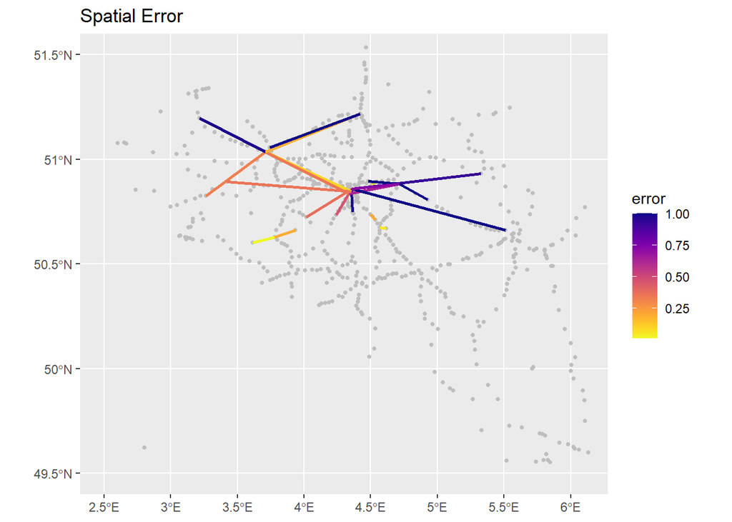

```r
ggplot(all_error)+
#geom_sf(data=rail,inherit.aes = FALSE, na.rm=T, col="black", lwd=0.2 ,alpha=0.2)+
geom_sf(data=stations, size = 1, inherit.aes = FALSE, col="grey" )+
geom_sf(data=all_error, aes(colour = error),lwd=1)+
    scale_colour_viridis(direction = -1, discrete = F, option = "C")+
     #facet_wrap(~type)+
    ylim(min(49.5), max(51.5))+ #lat
    xlim(min(2.5), max(6.1))+
   labs(title="Spatial Error ")
```

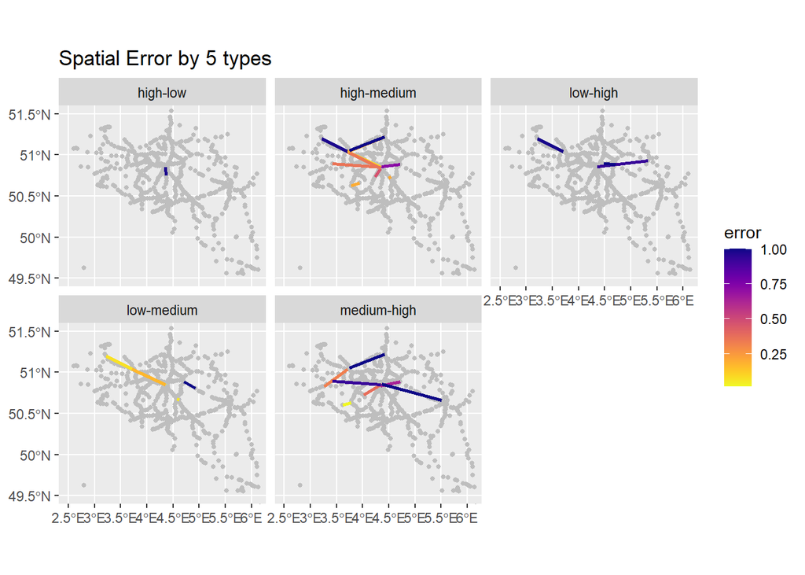

```r
ggplot(all_error)+
#geom_sf(data=rail,inherit.aes = FALSE, na.rm=T, col="black", lwd=0.2 ,alpha=0.2)+
geom_sf(data=stations, size = 1, inherit.aes = FALSE, col="grey" )+
geom_sf(data=all_error, aes(colour = error),lwd=1)+
    scale_colour_viridis(direction = -1, discrete = F, option = "C")+
     facet_wrap(~type)+
    ylim(min(49.5), max(51.5))+ #lat
    xlim(min(2.5), max(6.1))+
   labs(title="Spatial Error by 5 types")
```

For time error, we analysis the general time error and the time error of different types.

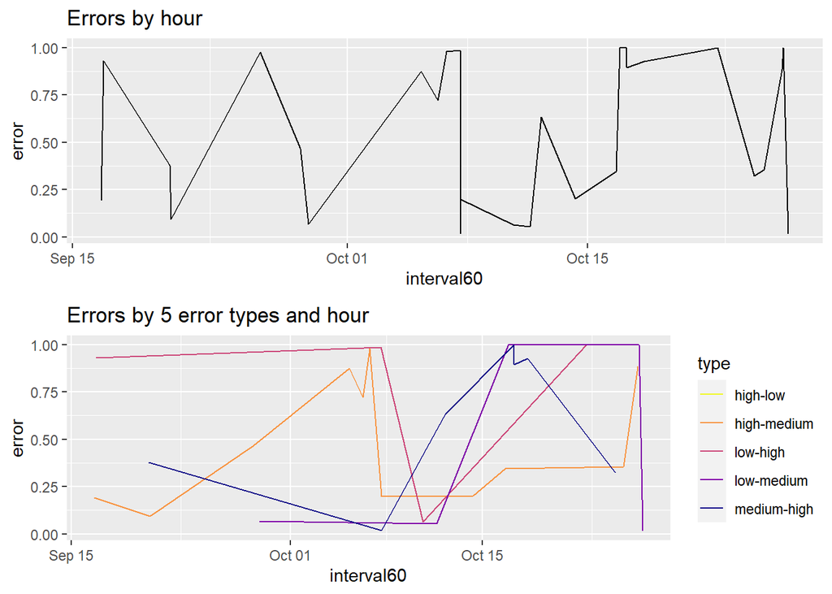

```r
all_error_df <- as.data.frame(all_error)

grid.arrange(
all_error %>%
  filter(interval60>=as.Date("2016-09-15"))%>%
    ggplot(aes(interval60, error)) +
      geom_line(size = 0.5)+
   labs(title = "Errors by hour")+
  scale_colour_viridis(direction = -1, discrete = T, option = "C")
  ,
all_error %>%
  filter(interval60>=as.Date("2016-09-15"))%>%
    ggplot(aes(interval60, error, colour=type)) +
      geom_line(size = 0.5)+
  labs(title = "Errors by 5 error types and hour")+
  scale_colour_viridis(direction = -1, discrete = T, option = "C"),
ncol=1)
```

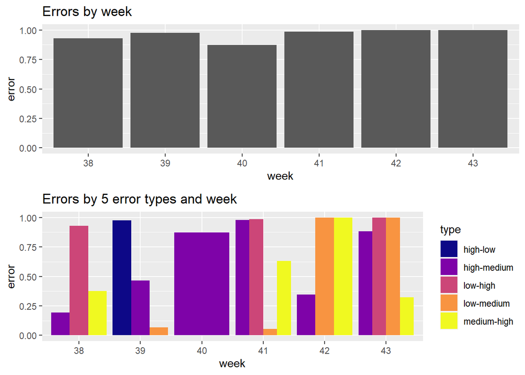

```r
grid.arrange(
  all_error %>%
  filter(week=="38"|week=="39"|week=="40"|week=="41"|week=="42"|week=="43")%>%
  ggplot(aes(x=week, y=error)) +
    geom_bar(position = "dodge", stat="identity") +
     scale_fill_manual(values =plasma(1))+
    labs(title = "Errors by week"),

all_error %>%
  filter(week=="38"|week=="39"|week=="40"|week=="41"|week=="42"|week=="43")%>%
  ggplot(aes(x=week, y=error)) +
    geom_bar(aes(fill = type), position = "dodge", stat="identity") +
     scale_fill_manual(values = plasma(5)) +
  scale_colour_viridis(direction = -1, discrete = T, option = "C")+
    labs(title = "Errors by 5 error types and week"),
ncol=1)
```

# 6. Conclusion and Further improvement

During this project we wants to introduce a feature that indicates the occupancy of each train in its data feeds, a system that accurately predicts the occupancy level of a train in the near future can have positive implications as the capacity of that train could be adapted, if possible, according to these predictions. This results on the one hand in a decreased probability of crowdy trains, thus an increase in the quality of service. On the other hand, a decrease in operational costs can be realized by reducing the capacity of trains that are expected to have a low occupancy.

We faced many challenges in the implementation process, such as NA value caused by multiple features, lack of timely available data, including price adjustment data, etc.